# Lab02 - Dynamic Computational Graphs (solution)

How different are computation in PyTorch from numpy? One main difference is that PyTorch constructs a computational network as it executes. The computation network allows for backpropagation where the gradients are computed, thus allowing us to update the parameter values. In this session, we shall learn how PyTorch works under the hood.

#### Objectives:

1. Learn how to perform forward propagation
2. Learn how to perform backward propagation
3. Understand how forward propagation builds a dynamic computational graph in PyTorch
4. Understand how backward propagation computes the gradient and destroys the dynamic computational graph

#### Content:

1. Computational Graph
2. Forward Propagation
   1. Building the computational graph dynamically
   2. Building on a as-needed basis
3. Backpropagation
   1. Retaining gradients of intermediate signals
   2. Backpropagation
   3. Clearing the gradients
4. Exercise

In this tutorial, we shall visualize the computed computational graph using `torchviz` which is a wrapper for the `graphviz` library. The following code install `torchviz` for Colab. For windows, you need to also install [graphviz](https://graphviz.org/download/) and add the application to the system path.

```python
# install torchviz
!pip install torchviz
```

```python
# install libraries
import torch
from torchviz import make_dot
```

## 1. Computational Graph

Different from *numpy* computations, a *deep learning framework* such as *TensorFlow* and *PyTorch* constructs a **computational network** as it runs. The computational graph is used to compute the **gradient** of the parameters, which in turn is used by the **Gradient Descent** algorithm to update the model parameters. The gradient descent algorithm is an iterative process that iterates between the following two steps:

1. **forward** propagation computes the predicted output of the training sample and the loss function $L$. In the process, the computational graph is built.
2. **backward** propagation computes the gradient of the parameters $\frac{dL}{dw_i}$. In the process, the computational graph is destroyed.

## 2. Forward Propagation

### 2.1 Building the computational graph dynamically

PyTorch builds the computational graph under the hood *on the fly* as you code. This makes PyTorch very pythonic and easy to debug. Let's see what is meant by dynamic network computation by implementing the following function.

$$out = \sum_{i=1}^M \tanh(\mathbf{W}_x\mathbf{x} + \mathbf{W}_h \mathbf{h})_i \tag{1}$$

We shall implement the function in several steps:

$$\mathbf{i2h} = \mathbf{W}_x.\mathbf{x}$$

$$\mathbf{h2h} = \mathbf{W}_h.\mathbf{h}$$

$$\mathbf{next\_h} = \mathbf{i2h} + \mathbf{h2h}$$

$$\mathbf{next\_h} = \tanh(\mathbf{next\_h})$$

$$out = \sum_{i=1}^M \mathbf{next\_h}_i$$

where:

- the parameters $\mathbf{W}_x$ and $\mathbf{W}_h$ are *random* tensors of size (3,2) and (3,3), respective
- the input $\mathbf{x}$ and $\mathbf{h}$ are *random* tensors of size (2,1) and (3,1), respectively.
- the intermediate tensors $\mathbf{i2h}$, $\mathbf{h2h}$ and $\mathbf{next\_h}$ are tensors of size (3,1)
- the output $out$ is a scalar

First, let's initialize `Wh`, `Wx`, `x` and `h`. For all of them, set its `requires_grad=True` to indicate that we wish to compute their gradients when we perform backpropagation later.

```python
# Initialize Wh, Wx, x, h
Wh = torch.randn(3,3, requires_grad=True)
Wx = torch.randn(3,2, requires_grad=True)
x  = torch.randn(2,1, requires_grad=True)
h  = torch.randn(3,1, requires_grad=True)

print('Wh:\n', Wh)
print('Wx:\n', Wx)
print('x:\n', x)
print('h:\n', h)
```

```
Wh:
 tensor([[-1.2874,  0.0476,  0.7289],
        [ 1.1908, -1.4095, -0.1450],
        [-1.2488,  1.2822,  1.3812]], requires_grad=True)
Wx:
 tensor([[ 1.0033, -1.4537],
        [ 0.7409,  0.3301],
        [-1.3191,  1.1860]], requires_grad=True)
x:
 tensor([[-0.4193],
        [-0.6554]], requires_grad=True)
h:
 tensor([[-0.2636],
        [-0.0171],
        [-0.8030]], requires_grad=True)
```

Now, let's compute i2h and h2h and then visualize what we have built

```python
# compute i2h and h2h
i2h = Wx @ x
h2h = Wh @ h

print('i2h:\n', i2h)
print('h2h:\n', h2h)
```

```
i2h:
 tensor([[ 0.5320],
        [-0.5270],
        [-0.2241]], grad_fn=<MmBackward0>)
h2h:
 tensor([[-0.2468],
        [-0.1733],
        [-0.8020]], grad_fn=<MmBackward0>)
```

First, let's visualize what we have built. To do that, we use `torchviz.make_dot` to visualize the computational graph. The following code. shows the computational graph that computes the `i2h` and `h2h`, respectively.

- `MmBackward0` is the backprop node created for a matrix multiplication operation (`@` or more specifically `torch.mm`).
- `AccumulateGrad` is a housekeeping node to accumulate the gradients at the leaf nodes.

```python
# visualize the computational graph for i2h
make_dot(i2h)
```

[figure not shown]

```python
# visualize the computational graph for h2h
make_dot(h2h)
```

[figure not shown]

Now, let's continue to implement our function by adding `i2h` and `h2h` and store it at `next_h`. When you visualize the computational graph, the two computational graphs above are connected through the `AddBackward0` which is the backprop node for `+` operation.

```python
# add i2h and h2h
next_h = i2h + h2h
print('next_h:\n', next_h)
```

```
next_h:
 tensor([[ 0.2852],
        [-0.7003],
        [-1.0261]], grad_fn=<AddBackward0>)
```

```python
# visualize the computational graph for next_h
make_dot(next_h)
```

[figure not shown]

Then, we subject `next_h` to tanh and name the output with the same name`next_h`.

```python
next_h = next_h.tanh()
print('next_h:\n', next_h)
```

```
next_h:
 tensor([[ 0.2778],
        [-0.6045],
        [-0.7723]], grad_fn=<TanhBackward0>)
```

```python
# visualize the computational graph for the new next_h
make_dot(next_h)
```

[figure not shown]

Note that since we use the same name `next-h` for the output signal as the input (also called `next_h`), `next_h` now refers to the most recent operation (`Tensor.tanh`) and not the previous operation (`+`)

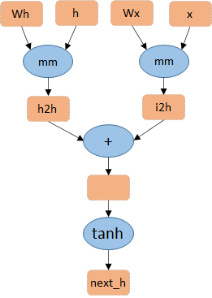

Now, sum all the items in vector `next_h` and store the output as `out`.

```python
# sum all items in next_h
out    = next_h.sum()
print('out:\n', out)
```

```
out:
 tensor(-1.0991, grad_fn=<SumBackward0>)
```

```python
# visualize the network for out
make_dot(out)
```

[figure not shown]

### 2.2 Building on a as needed basis

In the PyTorch framework, the computational graph is built on a as-needed basis where only the necessary part are constructed. For example, if we set the `requires_grad` only for $W_h$ and $W_x$ excluding $x$ and $h$, only a fraction of the computational graph will be constructed. It now no longer includes the nodes `h` and `x`.

```python
# Only enable the gradient comptuation for Wh and Wx
Wh = torch.randn(3,3, requires_grad=True)
Wx = torch.randn(3,2, requires_grad=True)
x  = torch.randn(2,1)  # gradient of x is not needed
h  = torch.randn(3,1)  # gradient of h is not needed

i2h = Wx@x
h2h = Wh@h

next_h = i2h + h2h
next_h = next_h.tanh()
out    = next_h.sum()
```

```python
make_dot(out)
```

[figure not shown]

The signals that involved in backpropagation will have `requires_grad=True` even if they are not set explicitly. You can check which signal is involved in backpropagation by checking their `requires_grad` property.

```python
print('Wh: requires_grad =', Wh.requires_grad)
print('Wx: requires_grad =', Wx.requires_grad)
print('h: requires_grad =',  h.requires_grad)
print('x: requires_grad =',  x.requires_grad)
print('i2h: requires_grad =', i2h.requires_grad)
print('h2h: requires_grad =', h2h.requires_grad)
print('next_h: requires_grad =', next_h.requires_grad)
print('out: requires_grad =', out.requires_grad)
```

```
Wh: requires_grad = True
Wx: requires_grad = True
h: requires_grad = False
x: requires_grad = False
i2h: requires_grad = True
h2h: requires_grad = True
next_h: requires_grad = True
out: requires_grad = True
```

# 3. Backpropagation

In this section, we shall perform backproagation to compute the gradients at $\mathbf{W}_x$ and $\mathbf{W}_h$.

### 3.1 Retaining gradients of intermediate signals

```python
# retain the gradients of next_h, i2h and h2h
next_h.retain_grad()
i2h.retain_grad()
h2h.retain_grad()
```

### 3.2 Backpropagation

We perform backward propagation from the signal that we want to differentiate. In the example above, backpropagating from $out$ gives us $\frac{\partial out}{\partial \mathbf{W}_h}$ and $\frac{\partial out}{\partial \mathbf{W}_x}$.

```python
# perform backpropagation
out.backward()
```

```python
print('gradient of Wx:\n', Wx.grad)
print('\ngradient of Wh:\n', Wh.grad)
```

```
gradient of Wx:
 tensor([[-0.0013,  0.0039],
        [-0.0547,  0.1630],
        [-0.0012,  0.0035]])

gradient of Wh:
 tensor([[0.0035, 0.0062, 0.0085],
        [0.1465, 0.2597, 0.3543],
        [0.0031, 0.0056, 0.0076]])
```

You can also access the gradients for other signals that you configured to retain gradients. For other signals, their gradients are `None`.

```python
# retained during backpropagation
print('gradient of i2h:', i2h.grad)
print('gradient of h2h:', h2h.grad)
print('gradient of next_h:', next_h.grad)

# requires_grad set to False
print('\ngradient of x:', x.grad)
print('gradient of h:', h.grad)
```

```
gradient of i2h: tensor([[0.0054],
        [0.2264],
        [0.0049]])
gradient of h2h: tensor([[0.0054],
        [0.2264],
        [0.0049]])
gradient of next_h: tensor([[1.],
        [1.],
        [1.]])

gradient of x: None
gradient of h: None
```

**Notes** ⚠️:

1. In PyTorch, **in-place operations** (like `+=`, `tanh_()`) can break backpropagation if the original tensor value is needed for gradient computation, leading to runtime errors. In addition, leaf tensors with requires_grad=True cannot be modified in-place unless you disable gradient computation.
2. Backpropagation **destroys** the computational graph where the intermediate states used to compute the gradients are freed to save memory. Therefore you cannot call `backward` twice.

### 3.3 Clearing the gradients

PyTorch does **not overwrite** the gradient each time you compute the gradient. Rather, it **accumulates** the gradient of the tensors that we have set `requires_grad=True`.

Consider the following function:

$$y = 2x$$

The gradient of $y$ is always:

$$\frac{dy}{dx} = 2$$

However, each time we perform **forward** and **backward** operation, the gradient will be accumulated in each iteration.

```python
# Create the tensor
x = torch.tensor(6., requires_grad=True)
```

```python
y = 2*x       # forward propagation
y.backward()  # backprop
print(x.grad) # dy/dx should be 2
```

```
tensor(2.)
```

```python
y = 2*x       # forward propagation
y.backward()  # backprop
print(x.grad) # dy/dx should be 2
```

```
tensor(4.)
```

```python
y = 2*x       # forward propagation
y.backward()  # backprop
print(x.grad) # dy/dx should be 2
```

```
tensor(6.)
```

To prevent the gradients from accummulating, we need to **reset** the gradients to zero before backpropagation through the command

`x.grad.zero_()`

This will allow us to get the fresh gradient in each iteration.

```python
y = 2*x          # forward propagation
x.grad.zero_()   # clear the gradient
y.backward()     # backprop
print(x.grad)    # dy/dx should be 2
```

```
tensor(2.)
```

```python
y = 2*x          # forward propagation
x.grad.zero_()   # clear the gradient
y.backward()     # backprop
print(x.grad)    # dy/dx should be 2
```

```
tensor(2.)
```

```python
y = 2*x          # forward propagation
x.grad.zero_()   # clear the gradient
y.backward()     # backprop
print(x.grad)    # dy/dx should be 2
```

```
tensor(2.)
```

### Exercise

Implement the following operations:

$$f(x,y,z) = (x^2 + y)z$$

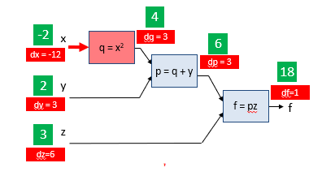

Expected ans:

```
df/dx = -12.0
df/dy = 3.0
df/dz = 6.0
df/dp = 3.0
df/dq = 3.0
```

```python
### START CODE HERE ###
# initialize x, y, z (3 lines)
x = torch.tensor(-2., requires_grad=True)
y = torch.tensor(2., requires_grad=True)
z = torch.tensor(3., requires_grad=True)

# forward propagate (1-3 lines)
q = x**2
p = q+y
f = p*z

# retain gradient for p and q (2 lines)
p.retain_grad()
q.retain_grad()

# perform backpropagation (1line)
f.backward()

### END CODE HERE ###
print('df/dx =', x.grad.item())
print('df/dy =', y.grad.item())
print('df/dz =', z.grad.item())
print('df/dp =', p.grad.item())
print('df/dq =', q.grad.item())
```

```
df/dx = -12.0
df/dy = 3.0
df/dz = 6.0
df/dp = 3.0
df/dq = 3.0
```

--- End of Lab02 ---